# TP3 : Modèle de Poisson et mélanges

# Première partie

On suppose les observations et de loi de Poisson de paramètre $\theta > 0$

1. On cherche la loi générative des données dans ce modèle.

$p(y|\theta) = p(y_1, y_2, ... y_n| \theta) = \displaystyle \prod_{i=1}^n \dfrac{\theta^{y_i}}{y_i!}e^{\theta}$

2. On suppose $p(\theta) \propto \dfrac{1}{\theta}$ avec $\theta > 0$.

On détermine la loi à posteriori du paramètre $\theta$.

$$\begin{eqnarray*}
p(\theta | y) & \propto & p(y|\theta)p(\theta) \\
& \propto & \theta^{\sum_{i=1}^n y_i - 1} e^{-n\theta} \displaystyle \prod_{i=1}^n \dfrac{1}{y_i!} \\
& \propto & \theta^{Y-1} e^{-n\theta}
\end{eqnarray*}$$

Donc $\theta|y \sim$ Gamma($Y$, $n$).

On a que l’espérance de la loi à posteriori vaut $E[\theta | y ] = \dfrac{Y}{n} = \dfrac{1}{n} \displaystyle \sum_{i=0}^n y_i$.

3. 4. 5. 6. Algorithme de Métropolis-Hasting

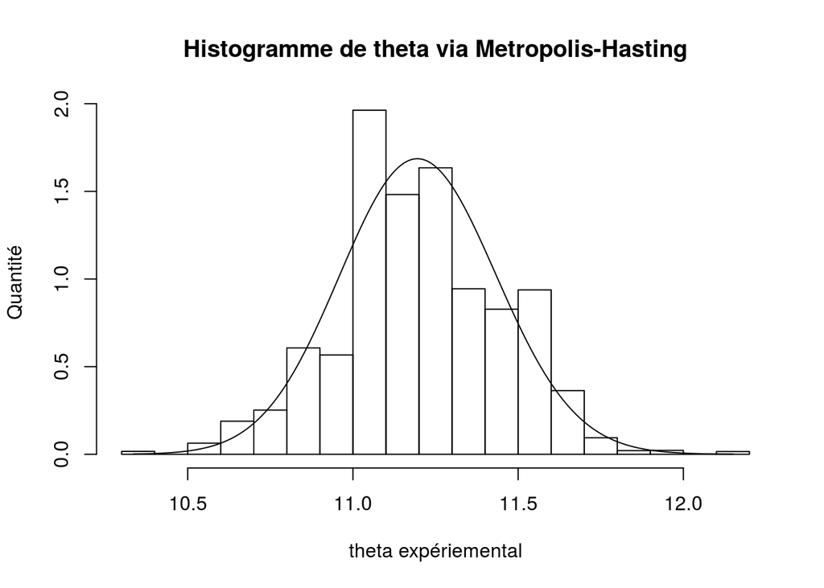

```r
# Problème rencontré pour l'algorithme de Métropolis-Hasting permet de "régler" ce problème :
options(warn=-1)

# Algorithme de Métropolis-Hasting
metropolis <- function(theta_init, nb_iter, y, burn) {

  n <- length(y)
  theta <- theta_init
  vect_theta <- c(1:nb_iter)

  for (i in 1:nb_iter) {


    theta_etoile <- rexp(1, rate = 1/theta)

    denom <- (dgamma(theta, sum(y), n) * dexp(theta_etoile, 1/theta))

    if (is.nan(denom)) {
      #print("Il y a eu un problème à l'éxécution. Néanmoins, l'algorithme de Métropolis s'est relancé automatiquement.")
      return(metropolis(theta_init, nb_iter, y, burn))
    }

    if (denom == 0) {
      R <- 1
    } else {
       R <- dgamma(theta_etoile, sum(y), n) * dexp(theta, 1/theta_etoile) / denom
    }

    u <- runif(1, 0, 1)

    if (u <= R) {
      theta <- theta_etoile
    }

    vect_theta[i] <- theta


  }

  return(vect_theta[burn:nb_iter])
}

# Valeur initiale de theta pour metropolis-hasting
theta_init <- 1


# y ensemble de valeur de loi de Poisson
# theta_theo <- 5 # à décommenter pour tester si ça marche bien avec une loi de Poisson
# y <- rpois(80, theta_theo) # à décommenter de même
y <- scan("tp3mpa.data")
nb_iter <- 10000

# Nbr de valeur souhaité burn << nb_iter
burn <- floor(nb_iter/10)


result <- metropolis(theta_init, nb_iter, y, burn)
hist(result, prob=TRUE, main = "Histogramme de theta via Metropolis-Hasting", xlab = "theta expériemental", ylab = "Quantité")
lines(seq(min(result), max(result), length.out = 1000), dgamma(seq(min(result), max(result), length.out = 1000), sum(y), length(y)))
```

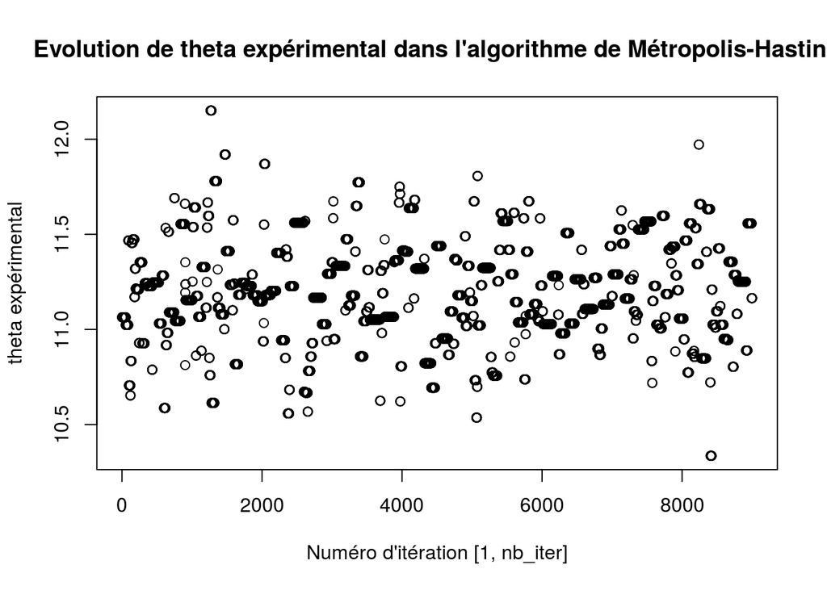

```r
plot(result, main = "Evolution de theta expérimental dans l'algorithme de Métropolis-Hasting", xlab = "Numéro d'itération [1, nb_iter]", ylab = "theta expérimental")
```

```r
# Moyenne de theta à posteriori
moy_theta <- mean(result)
print("Moyenne de theta à posteriori :")
```

```
## [1] "Moyenne de theta à posteriori :"
```

```r
moy_theta
```

```
## [1] 11.20114
```

```r
# Médiane de theta à posteriori
median_theta <- median(result)
print("Médiane de theta à posteriori:")
```

```
## [1] "Médiane de theta à posteriori:"
```

```r
median_theta
```

```
## [1] 11.18122
```

```r
# Intervalle de confiance à 95% de la moyenne de theta à posteriori
print("Intervalle de confiance à 95% de la moyenne de theta à posteriori")
```

```
## [1] "Intervalle de confiance à 95% de la moyenne de theta à posteriori"
```

```r
t.test(result)$conf.int
```

```
## [1] 11.19596 11.20631
## attr(,"conf.level")
## [1] 0.95
```

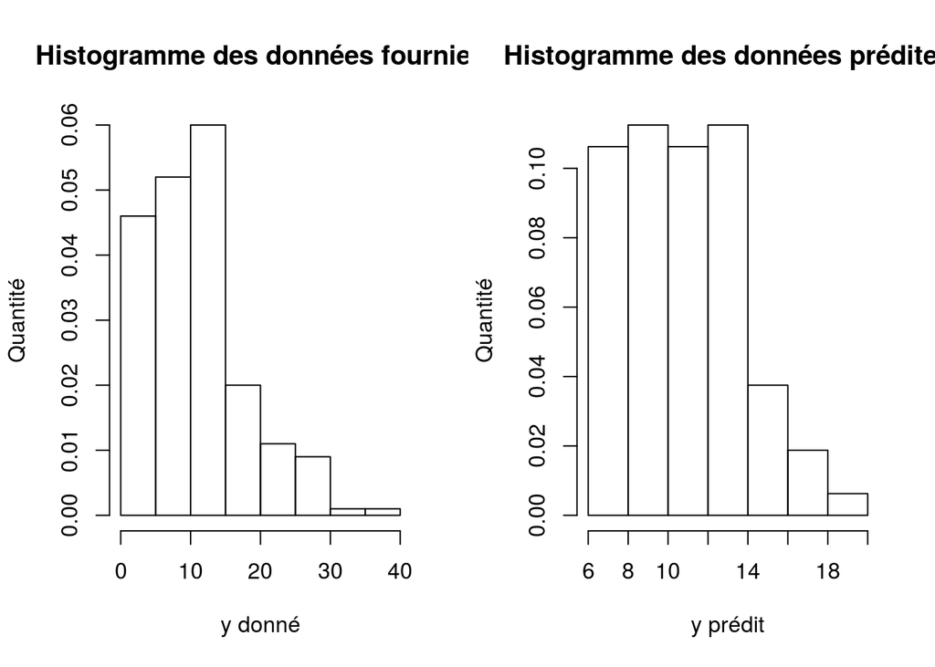

```r
simulation_predictive <- function(nbr_data_voulu, y) {

  theta <- rgamma(1, sum(y), length(y))
  y_prediction <- rpois(nbr_data_voulu, theta)

  return(y_prediction)
}

nbr_data_voulu <- 80
prediction <- simulation_predictive(nbr_data_voulu , y)

par(mfrow = c(1,2))
hist(y, prob=TRUE, main = "Histogramme des données fournies", xlab = "y donné", ylab = "Quantité")
hist(prediction, prob=TRUE, main = "Histogramme des données prédites", xlab = "y prédit", ylab = "Quantité")
```

On constate que l’histogramme des données prédites ne ressemble pas à l’histogramme des données fournies. Le pic vers la moyenne $\sim 11$ semble correspondre cependant on voit que pour les valeurs proches de zéro et plus grandes que 20 il y a un souci. Il semble alors préférable de ne pas supposer que l’ensemble des données proviennent d’une unique loi de Poisson.

# Seconde partie

On suppose désormais les $n$ données indépendantes et provenant de $K$ sources poissionniennes de moyennes inconnues $\theta = (\theta_1, \theta_2 ..., \theta_K)$. On définit les les $z = (z_1, z_2, ..., z_n)$ où $z_i \in \{1, K\}$ et le modèle $(y, z, \theta)$ ainsi :

$$p(y_i|z_i, \theta) = (\theta_{z_i})^{y_i} e^{-\theta_{z_i}}/y_i!$$
$$p(z) \propto 1$$

$$p(\theta_k) \propto 1/\theta_k$$

1. On détermine la loi à posteriori des $y$.

$$\begin{eqnarray*}
p(y|z, \theta) & = & \displaystyle \prod_{i=1}^n p(y_i|z_i, \theta) \\
& = & \displaystyle \prod_{k=1}^n \displaystyle \prod_{i \in I_k} p(y_i|z_i, \theta) \\
& = & \displaystyle \prod_{k=1}^n \displaystyle \prod_{i \in I_k} (\theta_{k})^{y_i} e^{-\theta_{k}}/y_i!
\end{eqnarray*}$$

2. On souhaite déterminer la loi à posteriori de $(z, \theta)$.

$$\begin{eqnarray*}
p(z,\theta|y) & \propto & p(y|z, \theta)p(z, \theta) \\
& \propto & p(y|z, \theta)p(z)p(\theta) \text{ par indépendance de $\theta$ et $z$}\\
& \propto & p(y|z, \theta) \times 1 \times p(\theta)\\
& \propto & \displaystyle \prod_{k=1}^n \dfrac{1}{\theta_k} \displaystyle \prod_{i \in I_k} (\theta_{k})^{y_i} e^{-\theta_{k}}/y_i!
\end{eqnarray*}$$

3. On veut déterminer $p(z_i = k | y, \theta)$.

On cherche en réalité la probabilité que $z_i = k$ sachant $y$ et $\theta$. Cela revient à chercher la probabilité que $y_i$ provienne de la loi de Poisson de paramètre $\theta_k$. On peut donc écrire :

$$p(z_i = k | y, \theta) = p(z_i = k | y_i, \theta)$$

Cela nous permet donc de trouver plus facilement une solution :

$$\begin{eqnarray*}
p(z_i = k|y, \theta) & = & p(y_i|z_i=k, \theta)\underbrace{p(z_i=k| \theta)}_{=1} / p(y_i|\theta) \\
& = & p(y_i|z_i=k, \theta) / \sum_{k=1}^K p(y_i|\theta, z_i=k) \underbrace{p(z_i = k|\theta)}_{=1}\\
& = & ((\theta_{k})^{y_i} e^{-\theta_{k}}/y_i!) / (\sum_{k=1}^K (\theta_{k})^{y_i} e^{-\theta_{k}}/y_i!)\\
& = & (\theta_{k})^{y_i} e^{-\theta_{k}} / \sum_{k=1}^K (\theta_{k})^{y_i} e^{-\theta_{k}}
\end{eqnarray*}$$

4. On a le développement suivant :

$$\begin{eqnarray*}
p(\theta_k|\theta_{-k},y,z) & = & \displaystyle \prod_{i \in I_k} p(\theta_k|\theta_{-k}, y_i, z_i = k) \\
& \propto & \displaystyle \prod_{i \in I_k} p(y_i|\theta,z_i)\underbrace{p(z_i|\theta_k, \theta_{-k})}_{p(z_i|\theta) = p(z_i) = 1} \underbrace{p(\theta_k| \theta_{-k})}_{p(\theta_k)} \\
& \propto & \displaystyle \prod_{i \in I_k} p(y_i|\theta,z_i)p(\theta_k) \\
& \propto & \theta_k^{n_k \bar{y_k}-1} e^{-n_k \theta_{k}}
\end{eqnarray*}$$

Donc finalement on a $\theta_k|\theta_{-k},y,z \sim$ Gamma($n_k \bar{x_k}$, $n_k$).

5. 6. On souhaite réaliser un algorithme de Gibbs permettant de simuler la loi à posteriori. En d’autres termes, on souhaite évaluer le vecteur de taille $K+n$ $(\theta, z)$.

On cherche donc à simuler $p(\theta, z|y)$. A noter que l’on laisse le choix à l’utilisateur du nombre $K$ c’est à dire du nombre de mélanges.

On peut donc commencer par initialiser le vecteur $\theta$ ou $z$ au choix. On a choisi d’initialiser $z$ pour implémenter notre algorithme. Attention, si vous choisissez d’implémenter en initialisant $\theta$ il faudra inverser l’étape a) et b) de l’algorithme.

L’algorithme va se dérouler ainsi :

Pour un nombre d’itération $N$ voulu et de préférence assez “grand”, on effectue la boucle suivante :

1. On simule $p(\theta|z, y)$ ce qui représente $K$ simulations de loi Gamma.
2. On simule $p(z| \theta,y)$ ce qui représente $n$ simulations.

Cet algorithme effectuera alors $N\times(K+n)$ simulations.

Voici l’implémentation de l’algorithme décris précédemment : (pour que le code soit plus facile à lire et à comprendre nous avons divisé le code en $4$ fonctions)

```r
simulation_theta <- function(z, y, K) {
  new_theta <- c(1:K)
  for (k in 1:K) {
    nk <- length(z[z==k])
    yk <- sum(y[z==k])/nk
    new_theta[k] <- rgamma(1, nk*yk, nk)
  }
 return(new_theta)
}

calc_sum_prob_yi <- function(yi, theta, K) {
  sum_prob_yi <- 0
  for (k in 1:K) {
    sum_prob_yi <- sum_prob_yi + theta[k]^yi * exp(-theta[k])
  }
  return(sum_prob_yi)
}

simulation_z <- function(theta, y, K) {
  n <- length(y)
  new_z <- c(1:n)
  for (i in 1:n) {

    p_zi_equal <- c(1:K)
    total_i <- calc_sum_prob_yi(y[i], theta, K)
    for(k in 1:K) {
      p_zi_equal[k] <-(theta[k]^y[i]*exp(-theta[k]))/total_i
    }
    new_z[i] <- sample(1:K, size = 1, replace = T, prob = p_zi_equal)
  }
  return(new_z)
}

gibbs <- function(nb_iter, K, y, z_init) {
  # Création des vecteurs theta et z
  theta <- c(1:K)
  theta_k <- c()
  z <- z_init
  for (i in 1:nb_iter) {
    theta <- simulation_theta(z, y, K)
    theta_k <- c(theta_k, theta)
    z <- simulation_z(theta, y, K)
  }
  return(c(theta_k, z))
}


#DOC de la fonction main_melange :
# nb_iter désigne le nombre de tour dans la boucle principale de l'algorithme de Gibbs
# K désigne le nombre de mélange
# burn désigne le nombre de première valeur qui ne seront pas pris en compte pour
# estimer les moyennes de theta_k pour k = 1 -> K
main_melange <- function(nb_iter, K, burn, prediction) {
  print("K = ")
  print(K)

  # Données fournies
  y <- scan("tp3mpa.data")
  n <- length(y)

  # Initialisation
  z_init <- sample(1:K, size = n, replace=T)

  result <- gibbs(nb_iter, K, y, z_init)
  theta <- result[1:(nb_iter*K)]
  moy_theta_k <- c(1:K)
  for (k in 0:(K-1)) {
    theta_k_temp <- theta[c(1:(nb_iter*K)) %% K == k]
    moy_theta_k[k+1] <- mean(theta_k_temp[burn:nb_iter]) # burn intervient ici
    #print(theta_k_temp)
  }
  z_exp <- result[(nb_iter*K+1):(nb_iter*K+n)]

  print("Espérance de theta_k sachant y :")
  for (k in 1:K) {
    print(moy_theta_k[k])
  }

  print("Proportion de chacune des composantes du mélange (trié dans l'ordre k = 1 -> K) :")
  z_prop <- c(1:K)
  for (k in 1:K) {
    z_prop[k] <- length(z_exp[z_exp == k])
  }
  print(z_prop)

  if (prediction) {
    return(c(moy_theta_k, z_prop))
  }

}

main_melange(1000, 3, 250, F)
```

```
## [1] "K = "
## [1] 3
## [1] "Espérance de theta_k sachant y :"
## [1] 2.26305
## [1] 19.48824
## [1] 10.50042
## [1] "Proportion de chacune des composantes du mélange (trié dans l'ordre k = 1 -> K) :"
## [1]  47 103  50
```

7. On va à présent voir pour quel $K$ le modèle semble être le plus pertinent. Nous allons donc effectuer plusieurs fois l’algorithme de Gibbs en faisant varier $K$.

```r
#---------- K = 1 -----------------------
main_melange(1000, 1, 250, F)
```

```
## [1] "K = "
## [1] 1
## [1] "Espérance de theta_k sachant y :"
## [1] 11.20595
## [1] "Proportion de chacune des composantes du mélange (trié dans l'ordre k = 1 -> K) :"
## [1] 200
```

Il est rassurant de constater que pour $K=1$ on retrouve bien en moyenne $\sim 11$, ce qui signifie que cet algorithme est en quelque sorte une extension du premier. On sait déjà que ce modèle est mauvais, il n’y a rien à ajouter de particulier ici.

```r
# --------- K = 2 -----------------------
y <- scan("tp3mpa.data")
n <- length(y)
K <- 2
tools <- main_melange(1000, K, 250, T)
```

```
## [1] "K = "
## [1] 2
## [1] "Espérance de theta_k sachant y :"
## [1] 15.08395
## [1] 4.312009
## [1] "Proportion de chacune des composantes du mélange (trié dans l'ordre k = 1 -> K) :"
## [1]  83 117
```

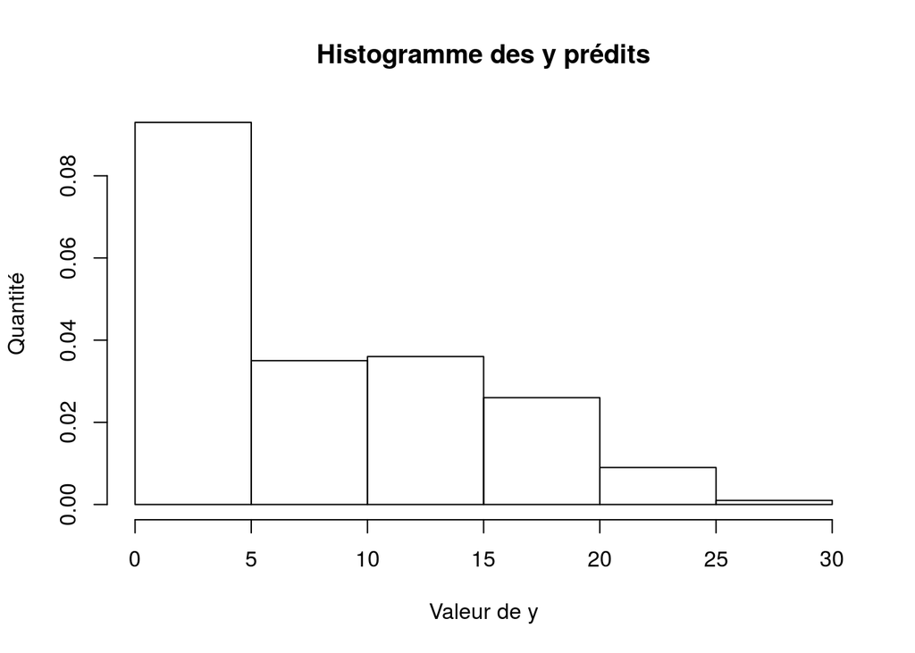

```r
moy_theta_K <- tools[1:K]
z_prop_K <- tools[(K+1):(2*K)]

proba <- z_prop_K/n
y_predictive <- c(1:n)
for (i in 1:n) {
  k <- sample(1:K, size = 1, replace = T, prob = proba)
  y_predictive[i] <- rpois(1, moy_theta_K[k])
}
hist(y_predictive, proba =TRUE, main = "Histogramme des y prédits", xlab = "Valeur de y", ylab = "Quantité")
```

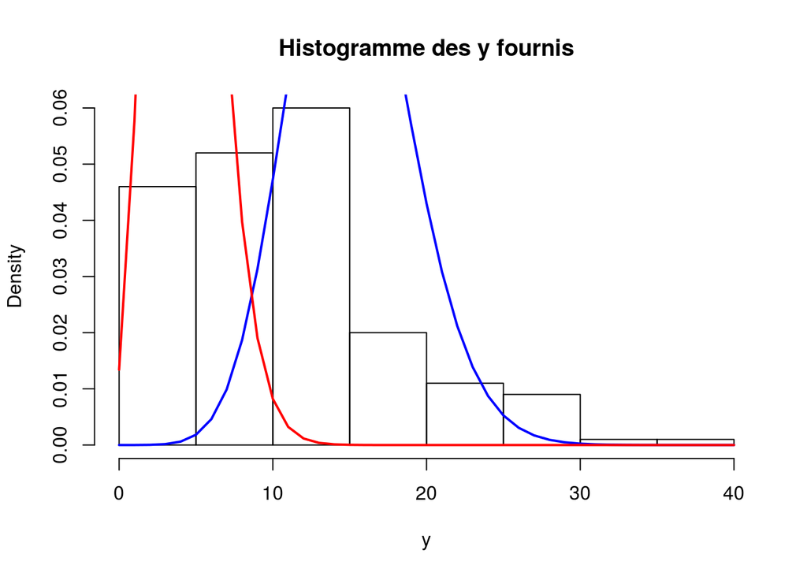

```r
hist(y, prob = TRUE, main = "Histogramme des y fournis")
lines(seq(0, 40), dpois(seq(0, 40), moy_theta_K[1]), col ="blue", lwd = 2)
lines(seq(0, 40), dpois(seq(0, 40), moy_theta_K[2]), col = "red", lwd = 2)
```

```r
# --------- K = 3 -----------------------
y <- scan("tp3mpa.data")
n <- length(y)
# Au vu de la dispertion des différentes valeurs de $y$ (via plot($y$)), on sent bien que K = 3 risque de bien correspondre.
K <- 3

tools <- main_melange(1000, K, 250, T)
```

```
## [1] "K = "
## [1] 3
## [1] "Espérance de theta_k sachant y :"
## [1] 2.304114
## [1] 19.59493
## [1] 10.59267
## [1] "Proportion de chacune des composantes du mélange (trié dans l'ordre k = 1 -> K) :"
## [1] 65 92 43
```

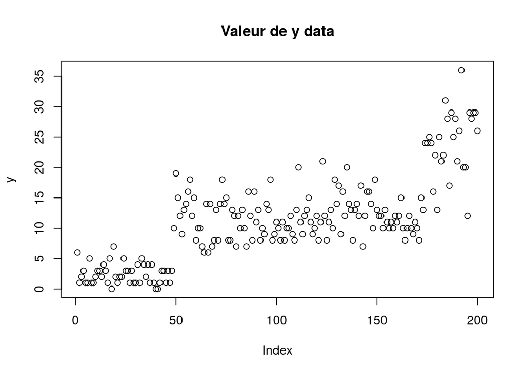

```r
plot(y, main = "Valeur de y data")
```

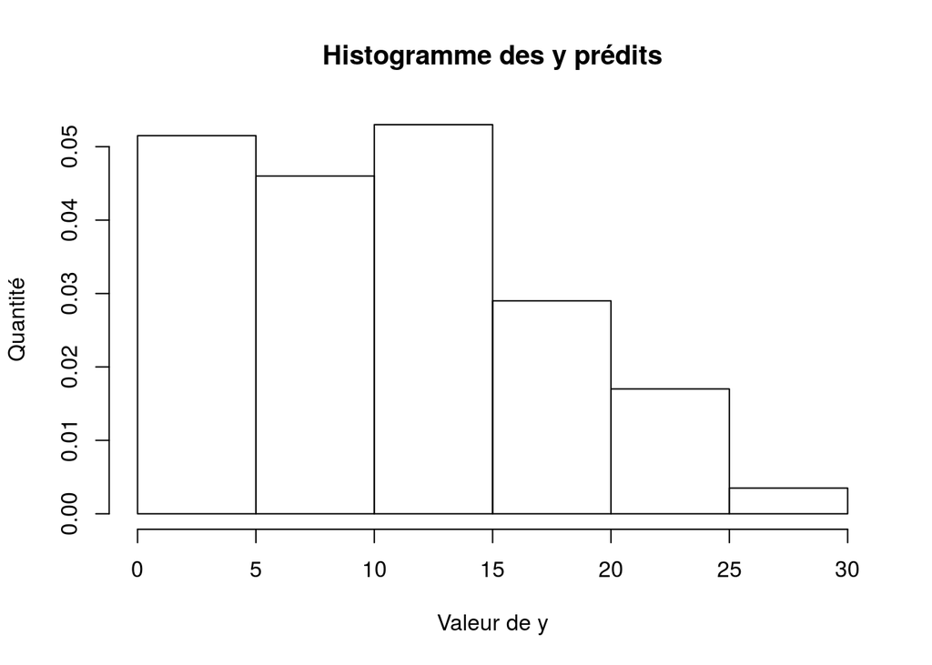

```r
moy_theta_K <- sort(tools[1:K])
z_prop_K <- tools[(K+1):(2*K)]

proba <- z_prop_K/n
y_predictive <- c(1:n)
for (i in 1:(2*n)) {
  k <- sample(1:K, size = 1, replace = T, prob = c(1/4, 1/2, 1/4))
  y_predictive[i] <- rpois(1, moy_theta_K[k])
}
hist(y_predictive, prob =TRUE, main = "Histogramme des y prédits", xlab = "Valeur de y", ylab = "Quantité")
```

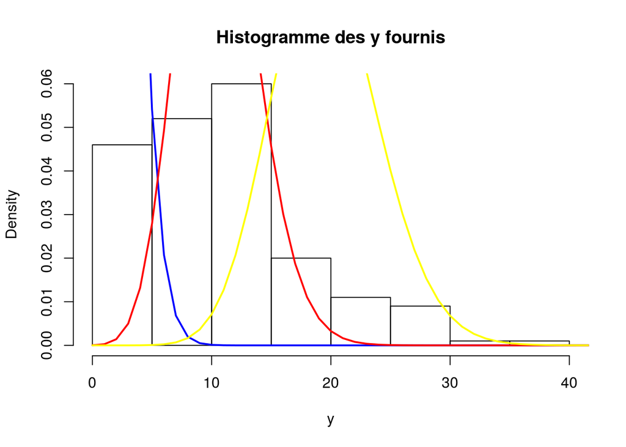

```r
hist(y, prob = TRUE, main = "Histogramme des y fournis")
lines(seq(0, 100), dpois(seq(0, 100), moy_theta_K[1]), col ="blue", lwd = 2)
lines(seq(0, 100), dpois(seq(0, 100), moy_theta_K[2]), col = "red", lwd = 2)
lines(seq(0, 100), dpois(seq(0, 100), moy_theta_K[3]), col = "yellow", lwd = 2)
```

```r
# --------- K = 4 -----------------------
y <- scan("tp3mpa.data")
n <- length(y)
K <- 4

main_melange(1000, K, 250, T)
```

```
## [1] "K = "
## [1] 4
## [1] "Espérance de theta_k sachant y :"
## [1] 10.95659
## [1] 11.12646
## [1] 22.36416
## [1] 2.18103
## [1] "Proportion de chacune des composantes du mélange (trié dans l'ordre k = 1 -> K) :"
## [1] 67 35 42 56
```

```
## [1] 10.95659 11.12646 22.36416  2.18103 67.00000 35.00000 42.00000 56.00000
```

```r
tools <- main_melange(1000, K, 250, T)
```

```
## [1] "K = "
## [1] 4
## [1] "Espérance de theta_k sachant y :"
## [1] 22.26088
## [1] 11.20245
## [1] 2.152573
## [1] 10.83482
## [1] "Proportion de chacune des composantes du mélange (trié dans l'ordre k = 1 -> K) :"
## [1] 63 43 45 49
```

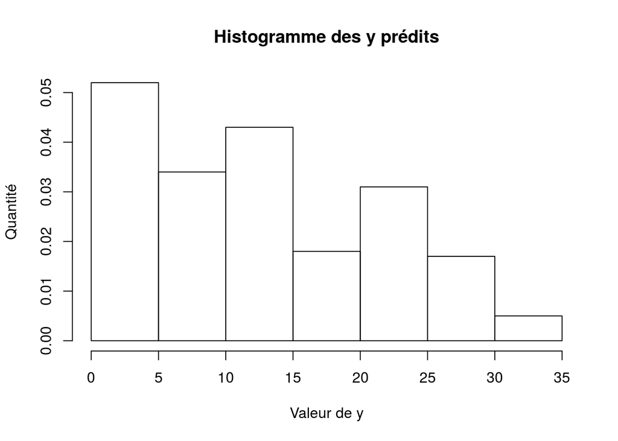

```r
moy_theta_K <- tools[1:K]
z_prop_K <- tools[(K+1):(2*K)]

proba <- z_prop_K/n
y_predictive <- c(1:n)
for (i in 1:n) {
  k <- sample(1:K, size = 1, replace = T, prob = proba)
  y_predictive[i] <- rpois(1, moy_theta_K[k])
}
hist(y_predictive, prob =TRUE, main = "Histogramme des y prédits", xlab = "Valeur de y", ylab = "Quantité")
```

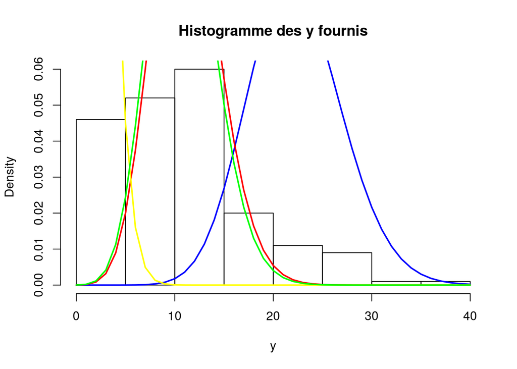

```r
hist(y, proba = TRUE, main = "Histogramme des y fournis")
lines(seq(0, 40), dpois(seq(0, 40), moy_theta_K[1]), col ="blue", lwd = 2)
lines(seq(0, 40), dpois(seq(0, 40), moy_theta_K[2]), col = "red", lwd = 2)
lines(seq(0, 40), dpois(seq(0, 40), moy_theta_K[3]), col = "yellow", lwd = 2)
lines(seq(0, 40), dpois(seq(0, 40), moy_theta_K[4]), col = "green", lwd = 2)
```

```r
# --------- K = 5 -----------------------

#Test supplémentaire pour des valeurs plus grandes de K

main_melange(1000, 5, 250, F)
```

```
## [1] "K = "
## [1] 5
## [1] "Espérance de theta_k sachant y :"
## [1] 23.47327
## [1] 2.066431
## [1] 11.14847
## [1] 11.18785
## [1] 11.29702
## [1] "Proportion de chacune des composantes du mélange (trié dans l'ordre k = 1 -> K) :"
## [1] 43 33 43 49 32
```

```r
# --------- K = 10 -----------------------

main_melange(1000, 10, 250, F)
```

```
## [1] "K = "
## [1] 10
## [1] "Espérance de theta_k sachant y :"
## [1] 9.846754
## [1] 11.55445
## [1] 4.257415
## [1] 5.980545
## [1] 15.58694
## [1] 11.895
## [1] 15.7352
## [1] 15.33399
## [1] 7.300211
## [1] 14.5925
## [1] "Proportion de chacune des composantes du mélange (trié dans l'ordre k = 1 -> K) :"
##  [1] 18 20 22 12 17 22 21 26 16 26
```

Bilan :

Au vu des différents résultats pour des $K$ différents, on conclut que le meilleur modèle est celui pour $K=3$.

En effet, pour $K<3$ l’histogramme des données prédites ne correspond pas du tout avec l’histogramme des données fournies. On conlut rapidement que ces modèles ne sont pas pertinents.

Cependant, même si le modèle pour $K=3$ semble être celui qui correspond le plus on est en droit de le critiquer tout de même. En effet, lorsque l’on prédit des nouvelles valeurs de $y$, on constate qu’il y a plus de valeurs proches de zéro et de $20$ que dans les données fournies (voir histogramme des données prédites pour $K=3$, code éxécutable juste au dessus). On peut alors se demander finalement si ces données ne proviennent pas d’un autre type de mélange avec d’autres lois éventuellement différentes.